# COSC 130 - Project 01

### Cynthia Feiteira

In this project we will be creating a linear regression model with the given information. Using the data we have on these models of vehicles since 1983 (with 398 models) we will be predicting the MPG based off the weight of the vehicle.

```python
import pandas as pd
import matplotlib.pyplot as plt
```

## Part 1: Importing and Viewing the Data

We will be importing and viewing the data.

```python
df = pd.read_table(filepath_or_buffer='auto_data.txt', sep='\t')
weight = list(df.wt)
mpg = list(df.mpg)
ln_mpg = list(df.ln_mpg)
```

I will now confirm that each list conain 398 values

```python
print(len(weight))
print(len(mpg))
print(len(ln_mpg))
```

```
398
398
398
```

I will be viewing the first 10 vehicles in the given data

```python
first_weight = weight[:10]
first_mpg = mpg[:10]
first_ln_mpg = ln_mpg[:10]



print(f'{"Weight":<6}{"MPG":>8}{"LN_MPG":>10}')
print(f'------------------------')
for i in range(0, len(first_weight)):
    print('{:<6}'.format(first_weight[i]),'{:^8}'.format(first_mpg[i]), '{:^10.4f}'.format(first_ln_mpg[i]))
```

```
Weight     MPG    LN_MPG
------------------------
3190     27.2     3.3032
1985     32.8     3.4904
3410     18.1     2.8959
4080     17.5     2.8622
3530     25.4     3.2347
1773     31.0     3.4340
2670     27.4     3.3105
1755     39.1     3.6661
2188     34.3     3.5351
2155     30.0     3.4012
```

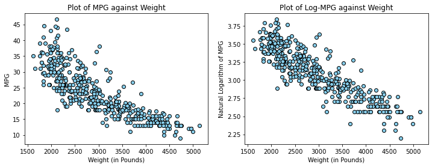

```python
plt.figure(figsize=[12,4])
plt.subplot(1,2,1)
plt.scatter(weight, mpg, c='skyblue', edgecolor='k')
plt.xlabel('Weight (in Pounds)')
plt.ylabel('MPG')
plt.title('Plot of MPG against Weight')
plt.subplot(1,2,2)
plt.scatter(weight, ln_mpg, c='skyblue', edgecolor='k')
plt.xlabel('Weight (in Pounds)')
plt.ylabel('Natural Logarithm of MPG')
plt.title('Plot of Log-MPG against Weight')
plt.show()
```

Comparing the miles per gallon and the natural log of MPG we see the difference with MPG being curved downwards and the natural log of MPG being more linear.

## Part 2: Splitting the Data

We will now attempt to split the data into a traing set and a test set.

```python
x_train = weight[:300]
x_test = weight[-98:]
y_train = ln_mpg[:300]
y_test = ln_mpg[-98:]
mpg_train = mpg[:300]
mpg_test = mpg[-98:]

n_train = len(x_train)
n_test = len(x_test)


print(f'Training Set Size: {n_train}\nTest Set Size:{n_test:>7}')
```

```
Training Set Size: 300
Test Set Size:     98
```

Next, we will be creating a scatter plot to get a visual representation of the data for training and test sets in the cell above.

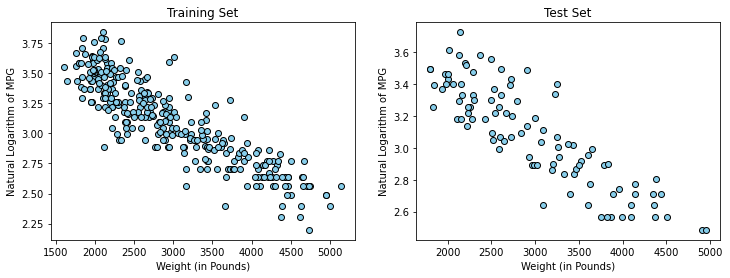

```python
plt.figure(figsize=[12,4])
plt.subplot(1,2,1)
plt.scatter(x_train, y_train, c='skyblue', edgecolor='k')
plt.xlabel('Weight (in Pounds)')
plt.ylabel('Natural Logarithm of MPG')
plt.title('Training Set')
plt.subplot(1,2,2)
plt.scatter(x_test, y_test, c='skyblue', edgecolor='k')
plt.xlabel('Weight (in Pounds)')
plt.ylabel('Natural Logarithm of MPG')
plt.title('Test Set')
plt.show()
```

## Part 3: Descriptive Statistics

In this part we will be calculating the mean of the weight and the log_MPG (using the values X and Y)

```python
mean_x = sum(x_train)/n_train
mean_y = sum(y_train)/n_train

print(f'Mean of X = {mean_x:.2f}')
print(f'Mean of Y = {mean_y:.4f}')
```

```
Mean of X = 2968.62
Mean of Y = 3.1069
```

We will now be calculating S(xx) and S(yy).

```python
Sxx = 0
for i in range(0, len(x_train)):
    Sxx += (x_train[i] - mean_x)**2

Syy = 0
for i in range(0, len(y_train)):
    Syy += (y_train[i] - mean_y)**2

print(f'Sxx = {Sxx:.2f}')
print(f'Syy = {Syy:.4f}')
```

```
Sxx = 224006920.44
Syy = 36.0746
```

We will now be calculating the variance of the training values of X and Y.

```python
var_x = Sxx/(n_train - 1)
var_y = Syy/(n_train - 1)

print(f'The Variance of X = {var_x:.2f}')
print(f'The Variance of Y = {var_y:.4f}')
```

```
The Variance of X = 749187.02
The Variance of Y = 0.1207
```

## Part 4: Linear Regression Model

in this part we will start to find the coefficients for a linear regression model as well as calculate Sxy.

```python
Sxy = 0
for i in range(0, len(x_train)):
    Sxy += (x_train[i] - mean_x)*(y_train[i] - mean_y)
print(f'Sxy = {Sxy:.2f}')
```

```
Sxy = -78999.13
```

in this section we will calculate the result in the previous cell calculate the coefficients of our model.

```python
beta_1 = Sxy/Sxx
beta_0 = mean_y - beta_1 * mean_x

print(f'beta_0 = {beta_0:.4f}')
print(f'beta_1 = {beta_1:.8f}')
```

```
beta_0 = 4.1538
beta_1 = -0.00035266
```

The next cell will have a visual representation of the regression line for the training set as well as the test set.

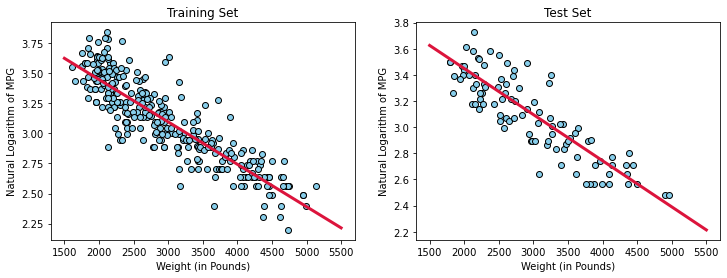

```python
y_vals = [beta_0 + beta_1 * 1500, beta_0 + beta_1 * 5500]
plt.figure(figsize=[12,4])
plt.subplot(1,2,1)
plt.scatter(x_train, y_train, c='skyblue', edgecolor='k')
plt.plot([1500,5500], y_vals, c='crimson', lw=3)
plt.xlabel('Weight (in Pounds)')
plt.ylabel('Natural Logarithm of MPG')
plt.title('Training Set')
plt.subplot(1,2,2)
plt.scatter(x_test, y_test, c='skyblue', edgecolor='k')
plt.plot([1500,5500], y_vals, c='crimson', lw=3)
plt.xlabel('Weight (in Pounds)')
plt.ylabel('Natural Logarithm of MPG')
plt.title('Test Set')
plt.show()
```

## Part 5: Training Score

The cell below will calculate the training r-squared score by calculating the estimated response values for the training set.

```python
pred_y_train = []
for i in range(0, len(y_train)):
    temp = beta_0 + beta_1 * x_train[i]
    pred_y_train.append(temp)
```

this next cell will have the calculated residuals for the training set.

```python
error_y_train = []
for i in range(0,len(y_train)):
    temps = y_train[i] - pred_y_train[i]
    error_y_train.append(temps)
```

The next cell will contain the values calculated from the above cells

```python
Pred_y = pred_y_train[:10]
Error_y = error_y_train[:10]
y_true = y_train[:10]



print(f'{"True y":<6}{"Pred y":>10}{"Error":>10}')
print(f'--------------------------')
for i in range(0,len(Pred_y)):
    print('{:<6.4f}'.format(y_true[i]), '{:^10.4f}'.format(Pred_y[i]), '{:^10.4f}'.format(Error_y[i]))
```

```
True y    Pred y     Error
--------------------------
3.3032   3.0289     0.2743
3.4904   3.4538     0.0366
2.8959   2.9513    -0.0554
2.8622   2.7150     0.1472
3.2347   2.9089     0.3258
3.4340   3.5286    -0.0946
3.3105   3.2122     0.0983
3.6661   3.5349     0.1312
3.5351   3.3822     0.1529
3.4012   3.3939     0.0073
```

Next we will calculate the sum of squared errors score for the training set

```python
sse_train = 0
for i in range(0, len(error_y_train)):
    sse_train += error_y_train[i]**(2)
print(f' Training SSE = {sse_train:.4f}')
```

```
 Training SSE = 8.2145
```

Now we will attempt to calculate the r-squared score for the training set.

```python
r2_train = 1-sse_train/Syy
print(f'Training r-Squared = {r2_train:.4f}')
```

```
Training r-Squared = 0.7723
```

## Part 6: Test Score

```python
pred_y_test = []
for i in range(0, len(x_test)):
    temp = beta_0 +beta_1 * x_test[i]
    pred_y_test.append(temp)
```

```python
error_y_test = []
for i in range(0, len(y_test)):
    temps = y_test[i] - pred_y_test[i]
    error_y_test.append(temp)
```

Next we will be giving a visual representation of the test scores

```python
Pred_test = pred_y_test[:10]
Error_test = error_y_test[:10]
next_test = y_test[:10]

print(f'{"True y":<6}{"Pred y":>10}{"Error":>10}')
print('--------------------------')
for i in range(0, len(Pred_test)):
    print('{:<6.4f}'.format(next_test[i]), '{:^10.4f}'.format(Pred_test[i]), '{:^10.4f}'.format(Error_test[i]))
```

```
True y    Pred y     Error
--------------------------
2.6391   3.0655     3.3462
2.8904   2.8190     3.3462
2.9957   2.8663     3.3462
2.5649   2.7890     3.3462
2.9957   3.2433     3.3462
2.9444   3.1205     3.3462
2.4849   2.4237     3.3462
3.2581   3.3586     3.3462
3.7257   3.3977     3.3462
2.5649   2.7474     3.3462
```

The next cell will calculate the sum of squared errors score for test set.

```python
sse_test = 0
for i in range(0, len(error_y_test)):
    sse_test += error_y_test[i]**(2)

print(f'Test SSE = {sse_test:.4f}')
```

```
Test SSE = 1097.3430
```

```python
r2_test = sse_test/Syy
print(f'Test r-Sqaured = {r2_test:.4f}')
```

```
Test r-Sqaured = 30.4187
```

now so see the visualized version of the previous cells we will creat a plot.

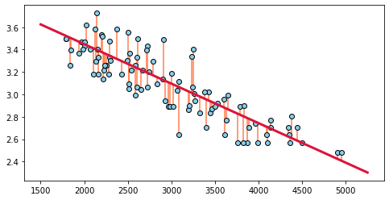

```python
plt.figure(figsize=[8,4])
plt.scatter(x_test, y_test, c='skyblue', edgecolor='k')
plt.plot([1500,5250], [beta_0 + beta_1 * 1500, beta_0 + beta_1 * 5250],
 c='crimson', lw=3)
for i in range(n_test):
 plt.plot([x_test[i], x_test[i]], [pred_y_test[i], y_test[i]],
 c='coral', zorder=0)
plt.show()
```

## Part 7: Transforming Test Predictions

This part will calculate the estimates for the average MPG for observations in our test set.

```python
e = 2.718281828
pred_mpg_test = []
for i in range(0, len(mpg_test)):
    tmp = e**(pred_y_test[i])
    pred_mpg_test.append(tmp)
```

the next cell calculates the error in each estimate for the average MPG.

```python
error_mpg_test = []
for i in range(0, len(mpg_test)):
    tempor = mpg_test[i] - pred_mpg_test[i]
    error_mpg_test.append(tempor)
```

the cell below will be a visual representation for the first 10 representations of the test set

```python
test_mpg = mpg_test[:10]
pred_mpg = pred_mpg_test[:10]
error_mpg = error_mpg_test[:10]

print(f'{"True MPG":<8}{"Pred MPG":>12}{"Error":>9}')
print('-----------------------------')
for i in range(0, len(Pred_test)):
    print('{:<8.1f}'.format(test_mpg[i]), '{:^12.1f}'.format(pred_mpg[i]), '{:^9.1f}'.format(error_mpg[i]))
```

```
True MPG    Pred MPG    Error
-----------------------------
14.0         21.4       -7.4
18.0         16.8        1.2
20.0         17.6        2.4
13.0         16.3       -3.3
20.0         25.6       -5.6
19.0         22.7       -3.7
12.0         11.3        0.7
26.0         28.7       -2.7
41.5         29.9       11.6
13.0         15.6       -2.6
```